# Presidential Elections in Pennsylvania: 1960-2020

Matt Grady

November 27, 2020

### Overview

Four steps:

- Scrape county-level election results for 1960-1996 from the web;
- Input results from 2000-2020 I got from the PA website;
- Create a plot that shows the state-level results over time;
- Create a map that shows the county-level results over time.

First I’ll load the required packages.

```r
library(tidyverse)
library(tidycensus)
library(rgdal)
library(sf)
library(xml2)
library(rvest)
```

### Getting the Data: 1960-1996

County-level results for the 1960 through 1996 presidential elections are available at http://staffweb.wilkes.edu/harold.cox/pres/indexpres.html. There is a separate web page for each election, and the pages are named in a standardized way. I’ll use the `xml2` package to scrape the data from the individual web pages.

```r
election.set = as.character(seq(1960,1996,4))  # List the elections I want data for

base.url = "http://staffweb.wilkes.edu/harold.cox/pres/PaPres"

e.list = list()
for (i in 1:length(election.set)){
  url = paste(base.url, election.set[i], sep='')
  url = paste(url, ".html", sep='') # Specify the url for the election
  e.list[[i]] = html_table(read_html(url), fill=T)[[1]]  # Put the data frame into a list
  e.list[[i]]$Election.Name = election.set[i] # Add an election identifier
}
```

I put the individual results data frames (one per election) into a list that I can apply a cleaning function to. Then I apply the cleaning function and combine everthing into a single data frame.

```r
df.clean = function(x) {  # Create the cleaning function
  x %>%
    filter(! County %in% c('','Pennsylvania')) %>%
    select_if(! names(.) %in% c('Total Vote', 'Plurality', 'Winner', 'Pct Rep', 'Pct Dem',
                                'Pct Other', 'Pct AIP', 'Pa Perot')) %>%
    mutate_if(is.numeric, as.character) %>%
    pivot_longer(! c(County, Election.Name), names_to="Party.Name", values_to="Votes") %>%
    rename(County.Name = County)
}
e.old = lapply(e.list, df.clean) # Apply the cleaning function to each data frame in the list
e.old = do.call(rbind.data.frame, e.old) # Combine everything into a single data frame
```

### Getting the Data: 2000-2020

I use a loop to input and clean the individual data sets. Then I combine everything into a single data frame.

```r
election.set2 = as.character(seq(2000,2020,4))  # List the election years

base.path = 'C:/Users/Matt/Desktop/Matt/2020-11-25/1. PA 2020 election/Data sets/'

e.list2 = list()
for (i in 1:length(election.set2)){
  path = paste(base.path, election.set2[i], sep='')
  path = paste(path, "_PA_county_results.txt", sep='') # specify the path to the csv file
  e.list2[[i]] = read.csv(file=path)  # input the csv file
  e.list2[[i]]$Election.Name = election.set2[i]
  e.list2[[i]] = e.list2[[i]][c('Election.Name','County.Name','Party.Name','Votes')]
}
e.new = do.call(rbind.data.frame, e.list2) # combine everything into one data frame
```

Finally, I combine the older election data (1960-1996) and the newer data (2000-2020). This gives me the base data frame on which all my subsequent analysis will be based.

```r
e.old = e.old[names(e.new)]
e = rbind(e.old, e.new) # bind the two data sets together

e$County.Name = toupper(e$County.Name) # convert county names to "all caps" for each merging
e$Votes = as.numeric(gsub(",","", e$Votes))  # Make the Votes field numeric with no commas

head(e)
```

```
## # A tibble: 6 x 4
##   Election.Name County.Name Party.Name       Votes
##   <chr>         <chr>       <chr>            <dbl>
## 1 1960          ADAMS       Republican       12933
## 2 1960          ADAMS       Democratic        7895
## 3 1960          ADAMS       Socialist Labor     11
## 4 1960          ADAMS       Workers              9
## 5 1960          ADAMS       Scattering           6
## 6 1960          ALLEGHENY   Republican      320970
```

### State-level Trends

First I’ll examine the results of each election in my sample. For each election, I’ll calculate the Democratic-Republican margin, which I define as the percentage of the vote won by the Democratic candidate minus the percentage won by the Republican candidate.

```r
election.margins = e %>%
  group_by(Election.Name, Party.Name) %>%
  summarize(Votes = sum(Votes, na.rm=T)) %>%
  mutate(Percent=Votes/sum(Votes, na.rm=T)*100) %>%
  summarize(D.Margin.Percent = Percent[Party.Name=='Democratic'] - Percent[Party.Name=='Republican']) %>%
  mutate(Winner = ifelse(D.Margin.Percent > 0, 'Democratic','Republican'))
```

Next I’ll create a bar plot to show the margin for each election.

```r
bar.plot = ggplot(election.margins, aes(x=Election.Name, y=D.Margin.Percent, fill=Winner)) +
  geom_bar(stat="identity") +
  scale_fill_manual(values=c("#2166ac", "#b2182b")) +
  scale_y_continuous(name='Dem. Margin (%)\n', breaks=seq(-20,30,5),
                     limits=c(-22,32), expand=c(0,0)) +
  scale_x_discrete(labels=c("'60","'64","'68","'72","'76","'80","'84","'88",
                            "'92","'96","'00","'04","'08","'12","'16","20")) +
  labs(title="Presidential Election Results for Pennsylvania: 1960-2020\n")
```

I’ll make some formatting changes to the bar plot …

```r
bar.plot = bar.plot +
  theme(
    axis.line = element_line(size=.5, color='gray50'),
    legend.position = "none",
    axis.text = element_text(size=11),
    axis.title.x = element_blank(),
    plot.title = element_text(size=13, face='bold', hjust=.5)
  )
```

and add a few annotations to highlight the elections with the largest margins.

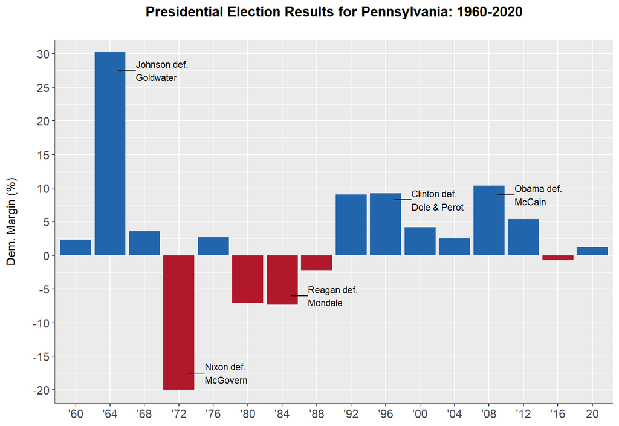

```r
bar.plot = bar.plot +
  geom_segment(aes(x=7.25, y=-6, xend=7.75, yend=-6)) +
  annotate("text", x=7.75, y=-6, hjust='left',
           label = "Reagan def.\nMondale", size=3, color='black') +
  geom_segment(aes(x=13.25, y=9, xend=13.75, yend=9)) +
  annotate("text", x=13.75, y=9, hjust='left',
           label = "Obama def.\nMcCain", size=3, color='black') +
  geom_segment(aes(x=2.25, y=27.5, xend=2.75, yend=27.5)) +
  annotate("text", x=2.75, y=27.5, hjust='left',
           label = "Johnson def.\nGoldwater", size=3, color='black') +
  geom_segment(aes(x=4.25, y=-17.5, xend=4.75, yend=-17.5)) +
  annotate("text", x=4.75, y=-17.5, hjust='left',
           label = "Nixon def.\nMcGovern", size=3, color='black') +
  geom_segment(aes(x=10.25, y=8.25, xend=10.75, yend=8.25)) +
  annotate("text", x=10.75, y=8.25, hjust='left',
           label = "Clinton def.\nDole & Perot", size=3, color='black')
bar.plot
```

The bar plot shows that the Democratic candidate has won 11 of the last 16 presidential elections in Pennsylvania, including seven of the last eight. Before Donald Trump’s win in 2016, a Republican candidate for president had not won Pennsylvania since George H.W. Bush defeated Michael Dukakis in 1988.

### County-level Trends

I’m primarily intested in learning about regional voting patterns have changed over time. I’ll start by calculating the Democratic-Republican margin for each Pennsylvania county, by election.

```r
county.margins = e %>%
  group_by(Election.Name, County.Name) %>%
  mutate(Percent = (Votes / sum(Votes, na.rm=T))*100) %>%
  summarize(Total.Votes = sum(Votes, na.rm=T),
            D.Margin.Percent = Percent[Party.Name=='Democratic'] - Percent[Party.Name=='Republican']) %>%  # Get the margin for each county
  mutate(Winner = ifelse(D.Margin.Percent > 0, 'Democratic','Republican')) # identify the winner

county.margins$margin.group = cut(county.margins$D.Margin.Percent, breaks=seq(80,-80,-20))
county.margins$margin.group = factor(county.margins$margin.group, levels=rev(levels(county.margins$margin.group))) # classify counties into groups based on margin
```

My first goal is to create a county-level choropleth map that shows the Democratic-Republican margin for each election. This will help me identify trends to focus on later.

In order to create the county-level map, I’ll need an appropriate shape file. I’ll use a shape file I obtained from the IPUMS National Historical Geographic Information System (NHGIS): https://www.nhgis.org/.

I’ll input the shape file and subset Pennsylvania counties. Then I’ll change the map projection, and create a “fortified” version of the file, which I’ll need to create the choropleth map with the `ggplot2` package.

```r
county.shape = readOGR("C:/Users/Matt/Desktop/Matt/2020-11-25/1. PA 2020 election/Shape files", "US_county_2018", verbose=F)

county.shape = county.shape[county.shape$STATEFP == '42',]

county.shape.sf = st_as_sf(county.shape)
county.shape.sf = st_transform(county.shape.sf, "+proj=longlat +ellps=WGS84 +datum=WGS84")
county.shape = as(county.shape.sf, 'Spatial')

county.shape$County.Name = toupper(sub(' .*', '', county.shape$NAME))
county.shape.fort = fortify(county.shape, region='County.Name') # fortify the shape file
```

Next I’ll combine the fortified county-level shape file with the election results data frame that contains the Democratic-Republican margin for each county, by election.

```r
county.margins$id = county.margins$County.Name
d = merge(county.shape.fort, county.margins, by='id') # combine shape file and data
d = d[order(d$order),]
```

Now I’ll use `ggplot2` to create the choropleth map.

```r
margin.map = ggplot() +
  geom_polygon(data=d,
               aes(x=long, y=lat, group=group, fill=margin.group),
               color='gray80', size=0.25) +
  scale_fill_manual(values=c('#2166ac','#4393c3','#92c5de','#d1e5f0',
                             '#fddbc7','#f4a582','#d6604d','#b2182b'),
                    name='Dem. Margin (%)') +
  labs(title="Presidential Election Results for Pennsylvania, by County: 1960-2020\n") +
  coord_map()
```

And add some additional formatting and specify the election year as a facet, which should allow me to get some sense of how voting patterns in counties and regions have changed over time.

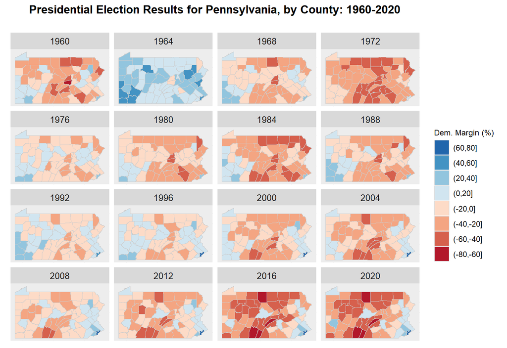

```r
margin.map = margin.map +
  theme(
    axis.title = element_blank(),
    axis.text = element_blank(),
    axis.ticks = element_blank(),
    panel.background = element_rect(fill='gray93'),
    panel.grid.major = element_line(color='gray93'),
    plot.title = element_text(size=13, face='bold', hjust=.5),
    strip.text = element_text(size=10),
    legend.title = element_text(size=9)
  ) +
  facet_wrap(~Election.Name, ncol=4) # facet by election
margin.map
```

```r
centroids = getSpPPolygonsLabptSlots(county.shape)
county.shape$X = centroids[,1]
county.shape$Y = centroids[,2]
cents = data.frame(county.shape$County.Name, county.shape$X, county.shape$Y)
names(cents) = c('County.Name','X','Y')

cents$X[cents$County.Name=='PHILADELPHIA'] = -74.9

d2 = merge(county.margins, cents, by='County.Name')
```

And now I’ll create the circle map …

```r
margin.map.circles = ggplot() +
  geom_polygon(data=d, aes(x=long, y=lat, group=group),
               color='gray85', fill='white', size=0.25) +
  geom_point(data=d2, aes(X, Y, size=Total.Votes, fill=margin.group),
             color='gray30', stroke=.5, shape=21) +
  scale_fill_manual(values=c('#2166ac','#4393c3','#92c5de','#d1e5f0',
                             '#fddbc7','#f4a582','#d6604d','#b2182b'),
                    name='Dem. Margin (%)') +
  scale_size_area(breaks=c(50000, 100000, 250000, 500000, 750000),
                  labels=c('50,000','100,000','250,000','500,000','750,000')) +
  labs(title="Presidential Election Results for Pennsylvania, by County: 1960-2020\n") +
  guides(fill=guide_legend(override.aes = list(size=4), order=1),
         size=guide_legend(override.aes = list(fill='white', color='black'), order=0)) +
  labs(size="Total Voters") +
  coord_map()
```

And add some additional formatting …

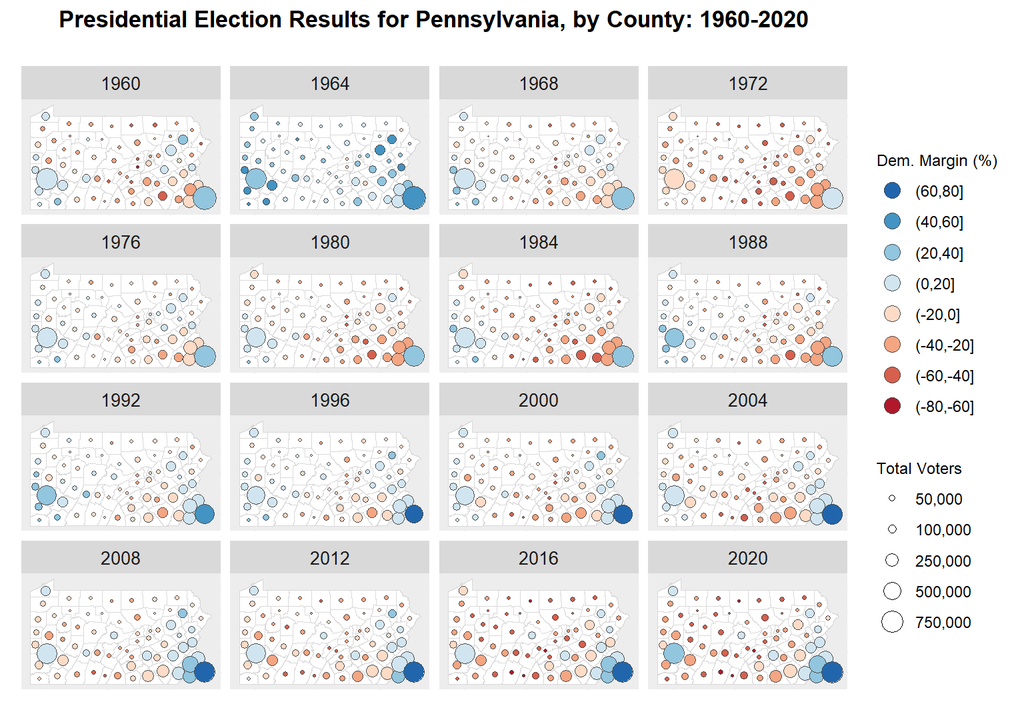

```r
margin.map.circles = margin.map.circles +
  theme(
    axis.title = element_blank(),
    axis.text = element_blank(),
    axis.ticks = element_blank(),
    panel.background = element_rect(fill='gray93'),
    panel.grid.major = element_line(color='gray93'),
    plot.title = element_text(size=13, face='bold', hjust=.5),
    strip.text = element_text(size=10),
    legend.title = element_text(size=9),
    legend.background = element_rect(color=NA, fill=NA),
    legend.key = element_rect(fill="transparent", colour="transparent")
  ) +
  facet_wrap(~Election.Name, ncol=4)
margin.map.circles
```

### Southwestern Border Counties

```r
sw.counties = c('LAWRENCE','BEAVER','WASHINGTON','WESTMORELAND','GREENE','FAYETTE')
```

Now I’ll calculate the Democratic-Republican margin, by election for the Southwest

```r
county.margins.sw = e %>%
  filter(County.Name %in% sw.counties) %>%
  group_by(Election.Name, Party.Name) %>%
  summarize(Total.Votes = sum(Votes, na.rm=T)) %>%
  group_by(Election.Name) %>%
  mutate(Percent = (Total.Votes / sum(Total.Votes, na.rm=T))*100) %>%
  summarize(D.Margin.Percent = Percent[Party.Name=='Democratic'] - Percent[Party.Name=='Republican']) %>%
  mutate(Winner = ifelse(D.Margin.Percent > 0, 'Democratic','Republican'))
```

Now I’ll create the initial bar plot.

```r
bar.plot.sw = ggplot(county.margins.sw, aes(x=Election.Name, y=D.Margin.Percent, fill=Winner)) +
  geom_bar(stat="identity") +
  scale_fill_manual(values=c("#2166ac", "#b2182b")) +
  scale_y_continuous(expand=c(0, 0), limits=c(-50, 75), breaks=seq(-50,70,10),
                     name='Dem. Margin (%)\n') +
  scale_x_discrete(labels=c("'60","'64","'68","'72","'76","'80","'84","'88",
                              "'92","'96","'00","'04","'08","'12","'16","'20")) +
  labs(title="Presidential Election Results for Southwestern Border Counties: 1960-2020\n")
```

Then add some formatting …

```r
bar.plot.sw = bar.plot.sw +
  theme(
    axis.title.x = element_blank(),
    axis.line = element_line(size=.5, color='gray50'),
    panel.background = element_rect(fill='gray93'),
    panel.grid.major = element_line(color='white'),
    panel.grid.minor = element_line(color='gray93'),
    legend.position = "none",
    plot.title = element_text(size=13, face='bold', hjust=.5)
  )
```

And some annotations …

```r
bar.plot.sw = bar.plot.sw +
  geom_segment(aes(x=7.65, y=29, xend=8, yend=23)) +
  annotate("text", x=7.5, y=31, hjust='right',
           label = "Dukakis won southwestern border\ncounties by 20+ points",
           size=3, color='black') +
  geom_segment(aes(x=14.1, y=-25, xend=14.75, yend=-25)) +
  annotate("text", x=14, y=-25, hjust='right',
         label = "Trump won southwestern border\ncounties by nearly 30 points",
         size=3, color='black')
```

I’ll create a map that I’ll inset into the bar plot to identify the counties I’m focusing on.

```r
d$southwest = ifelse(d$County.Name %in% sw.counties, 'southwest','other')
d$southwest = factor(d$southwest, levels=c('southwest','other'))

inset.map = ggplot() +
  geom_polygon(data=d, aes(x=long, y=lat, group=group, fill=southwest),
               color='white', size=0.25) +
  scale_fill_manual(values=c("gray30", "gray89"))
```

And add some formatting to the inset map …

```r
inset.map = inset.map +
  theme(
    axis.title = element_blank(),
    axis.text = element_blank(),
    axis.ticks = element_blank(),
    panel.background = element_rect(fill='white'),
    panel.grid.major = element_line(color='white'),
    plot.background = element_rect(color='black'),
    legend.title = element_text(size=9),
    legend.background = element_rect(color=NA, fill=NA),
    legend.position = "none"
  )
```

And finally, I’ll create the bar plot with the inset map included.

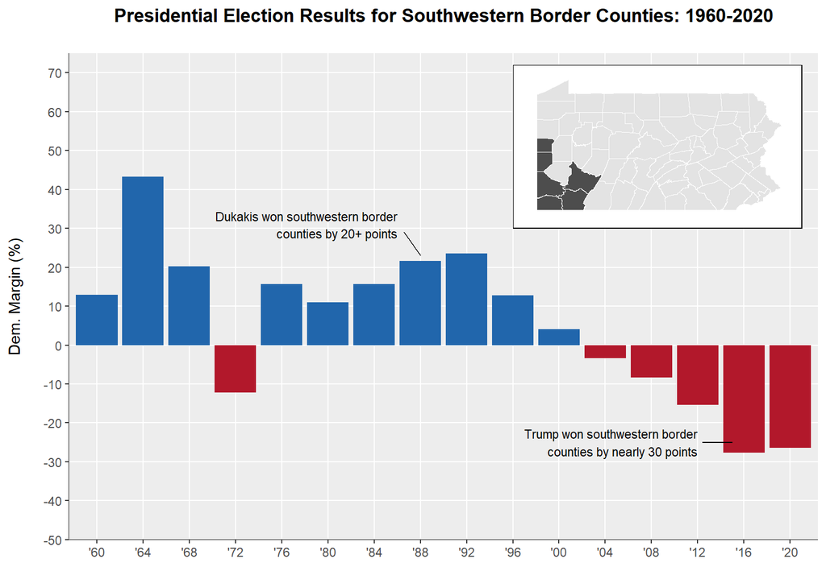

```r
bar.plot.sw = bar.plot.sw +
  annotation_custom(
    ggplotGrob(inset.map),
    xmin=10, xmax=16.25, ymin=30, ymax=72
  )
bar.plot.sw
```

### Suburban Philadelphia Counties

I’ll subset the counties I’m interested in.

```r
county.margins.se = county.margins %>%
  filter(County.Name %in% c('MONTGOMERY','BUCKS','CHESTER','DELAWARE')) %>%
  mutate(County.Name = factor(County.Name, levels=c('MONTGOMERY','BUCKS','CHESTER','DELAWARE')))
```

Now I’ll crate the bar plot to show the trends.

```r
labels.x = c("'60","","'68","","'76","","'84","","'92","","'00","","'08","","'16","")

bar.plot.se = ggplot(county.margins.se, aes(x=Election.Name,
                                            y=D.Margin.Percent, fill=Winner)) +
  geom_bar(stat="identity") +
  scale_fill_manual(values=c("#2166ac", "#b2182b")) +
  scale_y_continuous(breaks=seq(-40,30,10), limits=c(-45,35), expand=c(0,0),
                     name='Dem. Margin (%)\n') +
  scale_x_discrete(labels=labels.x, expand=c(.05,.05)) +
  labs(title="Presidential Election Results for Suburban Philadelphia Counties: 1960-2020\n")
```

And add some formatting …

```r
bar.plot.se = bar.plot.se +
  theme(
    legend.position = "none",
    axis.title.x = element_blank(),
    plot.title = element_text(size=13, face='bold', hjust=.5),
    strip.text = element_text(size=10)
  ) +
  facet_wrap(~County.Name, ncol=2)
```

And some annotations …

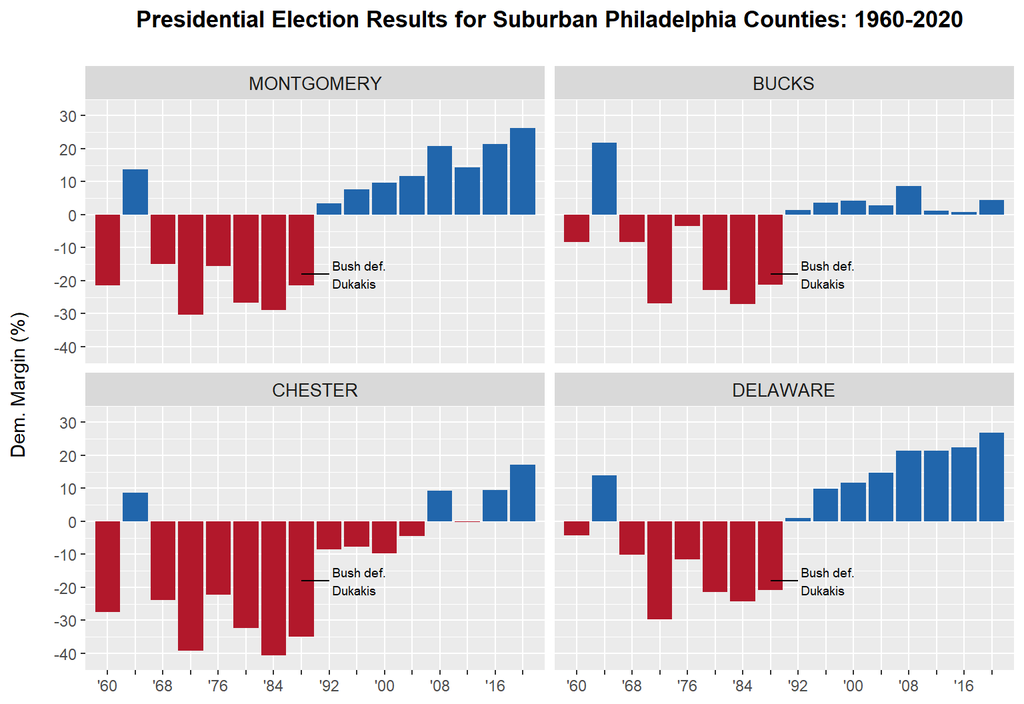

```r
bar.plot.se = bar.plot.se +
  geom_segment(aes(x=8, y=-18, xend=9, yend=-18)) +
  annotate("text", x=9.1, y=-18, hjust='left',
           label = "Bush def.\nDukakis",
           size=2.5, color='black')
bar.plot.se
```